# *Harm*

Philosophy 101 - Class 23

Brian Weatherson

weath@umich.edu

University of Michigan

November 15, 2023

# Background

## Consequentialism and Climate

Consequentialism is the view that morality is about consequences.

Good actions are those that bring about good results.

## Consequentialism and Risk

Problem: We don’t know what consequences our actions will have.

Solution: Good actions maximise **expected** value.

If there are a bunch of possible outcomes: $O_1, O_2, \dots$, the expected value is, where *Pr* measures how likely the outcome is, and *V* measures how good it is.

$$Pr(O_1)V(O_1) + Pr(O_2)V(O_2) + \dots$$
## Consequentialism and Demandingness

Problem: Standard versions say that only doing the best one can is good, everything else is a bad action.

Solution: Say (as many consequentialists do) that better actions produce better (expected) outcomes.

So Green in Nefsky’s example is very good, but she could be better. That sounds fine to me.

## Consequentialism and Groups

Problem: This makes more sense when it concerns harms that *I* might bring about. It does less well with harms that *we* might bring about.

Related problem: It makes sense for actions where there is a very direct cause-effect connection. It does much less well with actions where the consequences are very distant.

That’s what today’s class is about.

# A Puzzle

## Background

- 2000 people, including you, have a choice between an easy and a hard way to perform some task.
- The hard way won’t be more effort, but it will take five minutes longer.
- If 1000 or more people do things the easy way, a village on an island in the Pacific Ocean will be wiped out by floodwater.
- You are very confident that the vast majority of other people will do things the easy way.

## iClicker quiz

Does morality require you to do it the hard way?

1. Yes
2. No

## Argument for Yes

It’s a whole village, it’s five minutes more work, what are we even talking about?

## Argument for No

- The badness of the action is just due to the badness of its consequences.
- But it won’t in fact have any bad consequences.
- The village is gone whatever you do, because of all those other people.
- So there’s nothing wrong with doing things the easy way.

## Response to the No Argument

- Everyone else could say the same thing.
- So the village gets wiped out, and it’s no one’s fault.

## Counter-response

- It’s the government’s fault.
- This is a collective action problem, and the government should have solved it by banning doing things the easy way.
- But individuals should just follow the rules, with perhaps some exceptions.

# When To Avoid Harm

## Exceptions

There’s no law that says you have to rescue children drowning in ponds, but you still should do it.

So we need an exception to the “just follow the law” approach. Two options

1. You shouldn’t do something that you can see will harm another, even if it’s legal.
2. You shouldn’t do something that will in expectation harm another, even if it’s legal.

## Exceptions

- The first is going to mean that we have no climate obligations at all.
- The second is going to mean that we are obliged to be obsessives about climate.

## Visible Harm

There are two big problems here.

1. The chain of cause and effect between any polluting activity and any climate harm is so long and convoluted that we couldn’t possibly trace it.
2. Even if we could trace it, it might end up that some pollution ends up having a positive effect. Maybe the extra bit of heat changed the path of a hurricane and moved it away from a population center.

## Expected Harm

The problem here is that it rules out so much. It rules out Green taking a drive to go hiking.

- I think the solution here is simply to say that it is better to pollute less.
- If I give 20% of my income to good charities, and you give 30% of yours, what you’re doing is better than what I’m doing.
- It just seems like a mistake to say that therefore what I’m doing is bad.

# Do We Harm?

## Three Questions

1. Are our collective polluting activities harming present and future people? Yes of course they are.
2. Are our individual polluting activities harming present and future people? Much too hard to say.
3. Are our individual polluting activities probably harming present and future people? Are they reducing the expected value of the world? That’s a much more interesting question

## Collective Harm without Individual Harm

Think back to the 2000 people example.

That’s a case where if everyone does the easy thing, we all collectively harm the village.

But no one person even *probably* harms the village.

## Is Climate Change Like That?

It would be if these two conditions were met?

1. Climate change harms are step effects, with big jumps between harms.
2. We know that we are somewhere comfortably between two of the jumps.

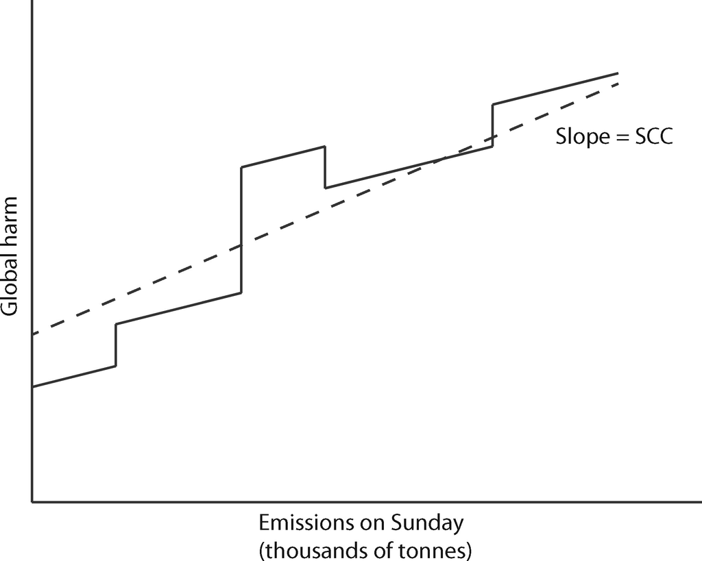

A graph from John Broome about one hypothesis about the relationship between pollution and harm. Note this is not Broome’s own view.

## Average and Marginal

If you contribute to pollution, or any other collectively harmful thing, we can define two important seeming values.

The **average** harm might be defined as the total harm we collectively do, divided by the number of people contributing to the harm.

The **marginal** harm is the harm we collectively do, minus the harm we would have done if you hadn’t contributed.

These can come apart.

## Average and Marginal

Indeed, in the village case they come dramatically apart.

- The average harm is massive; a village is wiped out.
- The marginal harm is **zero**; it would make no difference if you didn’t contribute.

## An Argument

Here is an argument that individuals do not share moral responsibility for harms due to climate change.

1. We’re only morally responsible if we know that our marginal harm is high.
2. We do not know that our marginal harm is high. We know our average harm is high, but that’s not the same thing.
3. Therefore, we’re not morally responsible.

## Two Responses

1. Say that average harms are really the morally significant factor. This is (roughly) what Nefsky ends up saying.
2. Say that **expected** marginal harms are really the morally significant factor. This is what Broome ends up saying.

## Expected Marginal Harm

For any pollution level $P$, say $EH(P)$ is our best guess about how much harm that pollution will cause.

- Strictly speaking, we mean the expected value of the amount of harm caused.
- This could be very different from the actual harm caused.
- We’ll write $H(P)$ for the actual harm caused.

## Expected Marginal Harm

Imagine you’re thinking engaging in some polluting activity.

Write $P-high$ for the amount of pollution there will be in total if you do it, and $P-low$ for the amount of pollution there will be if you don’t.

## Three Definitions

**Average Harm**

$H(P-high)/$(Number of polluters)

**Actual Marginal Harm**

$H(P-high) - H(P-low)$

**Expected Marginal Harm**

$EH(P-high) - EH(P-low)$

Big question - which of these matters morally?

# What are the Expected Harms

## Harm Jumps

In the village example I gave you, I basically stipulated that those two conditions were met.

1. I said that the harm would come at a tipping point, when 1000 people did the easy/wrong thing.
2. And I said that we know that we are nowhere near the tipping point.

Is the real world often like that?

## Harm Jumps

The short version is that no of course it isn’t.

We have no idea where the jumps will take place.

And everything else is secondary.

## Harm Jumps

If we had all day, I’d go over other ways in which the relationship between pollution and harm might be subject to ‘threshold effects’.

That is, cases where the amount is mostly insensitive to how much pollution there is, but jumps dramatically at some point.

There could be, in principle, jumps at any of:

1. Our actions -> pollution levels.
2. Pollution levels -> climactic effects.
3. Climatic effects -> harms to humans.

## Air Travel

Let’s just do one example, the first, to think about the moral considerations. Here’s an argument you might hear sometimes.

1. While planes are very polluting, the big determinant of pollution is whether they fly, not how much they fly.
2. My flying or not flying to Los Angeles makes no difference to how many planes fly to Los Angeles.
3. So, my flying or not flying to Los Angeles makes no difference to how much pollution there is.

## Air Travel

The first premise isn’t strictly true, the extra weight does make a difference.

But from the expected value perspective, the big thing is that the second premise is false.

For every 200 people per day fewer that fly to LA, Delta will put on one fewer plane.

There are threshold effects here, but every time you cross the threshold, a big thing happens - one fewer plane in the sky.

## Air Travel

Unless you know Delta is nowhere near adding or subtracting a plane from the schedule, the expected change in pollution from your travel plans exactly equals the average pollution per person of flying to Los Angeles.

The same goes for meat eating, and other forms of collective pollution.

## Summary

One argument against individual responsibility for climate change is:

1. Pollution works like the village example; there are big jumps in the activity -> harm relationship.
2. In those cases, our individual actions don’t harm, so we’re not responsible for the harm caused.

There are (at least) two responses to this:

1. We should still care about the average harm.
2. It’s only in artificial models like this that we know we aren’t harming, and that’s morally important.